# Sliding Windows Analysis

Anadromous Populations, Size 50kb step 10kb

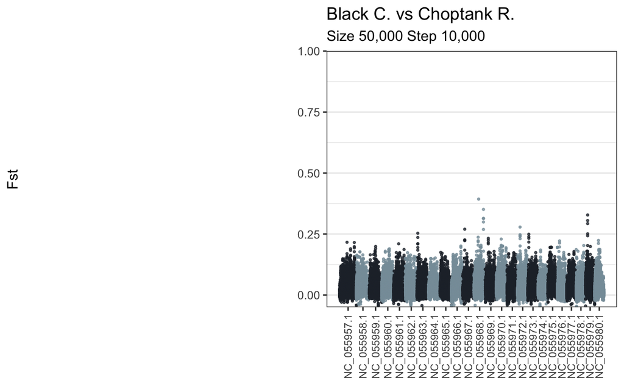

```r
BlC_ChR_plot <- ggplot(data = BlC_ChR,
                       mapping = aes(x = pos_cum,
                                     y = Fst,
                                     color = as_factor(chr))) +
  geom_point(alpha = 0.75, size = 0.5) +
  scale_x_continuous(label = BlC_ChR_axis_set$chr,
                     breaks = BlC_ChR_axis_set$center) +
  scale_y_continuous(expand = c(0,0),
                     limits = c(-0.05, 1)) +
  scale_color_manual(values = rep(c("#242b35", "#869ca8"),
                                  unique(length(BlC_ChR_axis_set$chr)))) +
  labs(x = NULL,
       y = "Fst",
       title = "Black C. vs Choptank R.",
       subtitle = "Size 50,000 Step 10,000") +
  theme_bw() +
  theme(legend.position = "none",
        panel.grid.major.x = element_blank(),
        panel.grid.minor.x = element_blank(),
        axis.title.y = element_markdown(),
        axis.text.x = element_text(angle = 90,
                                  size = 8,
                                  vjust = 0.5))
BlC_ChR_plot
```

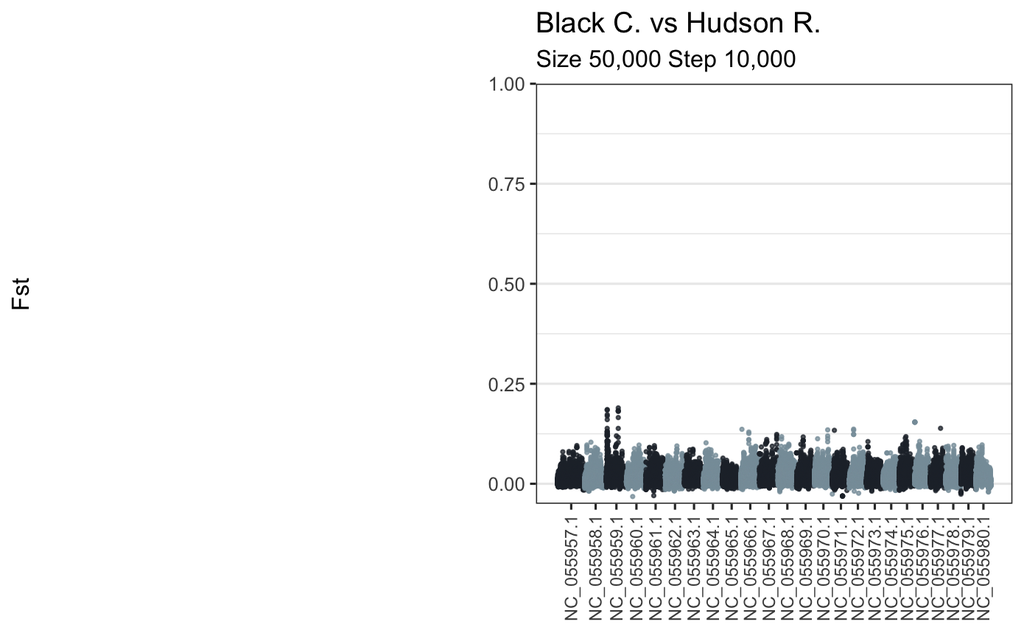

```r
BlC_HdR_plot <- ggplot(data = BlC_HdR,
                       mapping = aes(x = pos_cum,
                                     y = Fst,
                                     color = as_factor(chr))) +
  geom_point(alpha = 0.75, size = 0.5) +
  scale_x_continuous(label = BlC_HdR_axis_set$chr,
                     breaks = BlC_HdR_axis_set$center) +
  scale_y_continuous(expand = c(0,0),
                     limits = c(-0.05, 1)) +
  scale_color_manual(values = rep(c("#242b35", "#869ca8"),
                                  unique(length(BlC_HdR_axis_set$chr)))) +
  labs(x = NULL,
       y = "Fst",
       title = "Black C. vs Hudson R.",
       subtitle = "Size 50,000 Step 10,000") +
  theme_bw() +
  theme(legend.position = "none",
        panel.grid.major.x = element_blank(),
        panel.grid.minor.x = element_blank(),
        axis.title.y = element_markdown(),
        axis.text.x = element_text(angle = 90,
                                  size = 8,
                                  vjust = 0.5))
BlC_HdR_plot
```

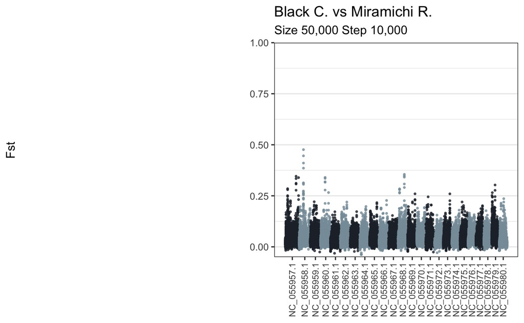

```r
BlC_MrR_plot <- ggplot(data = BlC_MrR,
                       mapping = aes(x = pos_cum,
                                     y = Fst,
                                     color = as_factor(chr))) +
  geom_point(alpha = 0.75, size = 0.5) +
  scale_x_continuous(label = BlC_MrR_axis_set$chr,
                     breaks = BlC_MrR_axis_set$center) +
  scale_y_continuous(expand = c(0,0),
                     limits = c(-0.05, 1)) +
  scale_color_manual(values = rep(c("#242b35", "#869ca8"),
                                  unique(length(BlC_MrR_axis_set$chr)))) +
  labs(x = NULL,
       y = "Fst",
       title = "Black C. vs Miramichi R.",
       subtitle = "Size 50,000 Step 10,000") +
  theme_bw() +
  theme(legend.position = "none",
        panel.grid.major.x = element_blank(),
        panel.grid.minor.x = element_blank(),
        axis.title.y = element_markdown(),
        axis.text.x = element_text(angle = 90,
                                  size = 8,
                                  vjust = 0.5))
BlC_MrR_plot
```

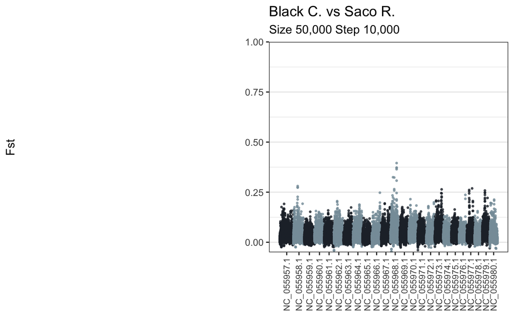

```r
BlC_ScR_plot <- ggplot(data = BlC_ScR,
                       mapping = aes(x = pos_cum,
                                     y = Fst,
                                     color = as_factor(chr))) +
  geom_point(alpha = 0.75, size = 0.5) +
  scale_x_continuous(label = BlC_ScR_axis_set$chr,
                     breaks = BlC_ScR_axis_set$center) +
  scale_y_continuous(expand = c(0,0),
                     limits = c(-0.05, 1)) +
  scale_color_manual(values = rep(c("#242b35", "#869ca8"),
                                  unique(length(BlC_ScR_axis_set$chr)))) +
  labs(x = NULL,
       y = "Fst",
       title = "Black C. vs Saco R.",
       subtitle = "Size 50,000 Step 10,000") +
  theme_bw() +
  theme(legend.position = "none",
        panel.grid.major.x = element_blank(),
        panel.grid.minor.x = element_blank(),
        axis.title.y = element_markdown(),
        axis.text.x = element_text(angle = 90,
                                  size = 8,
                                  vjust = 0.5))
BlC_ScR_plot
```

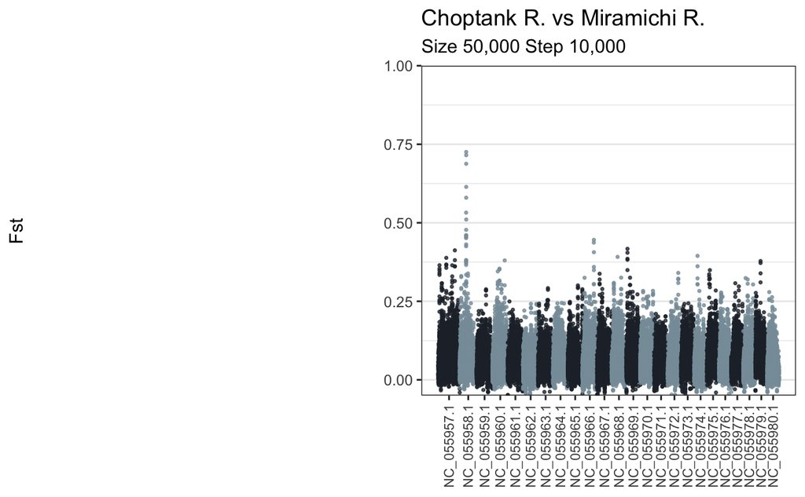

```r
ChR_MrR_plot <- ggplot(data = ChR_MrR,
                       mapping = aes(x = pos_cum,
                                     y = Fst,
                                     color = as_factor(chr))) +
  geom_point(alpha = 0.75, size = 0.5) +
  scale_x_continuous(label = ChR_MrR_axis_set$chr,
                     breaks = ChR_MrR_axis_set$center) +
  scale_y_continuous(expand = c(0,0),
                     limits = c(-0.05, 1)) +
  scale_color_manual(values = rep(c("#242b35", "#869ca8"),
                                  unique(length(ChR_MrR_axis_set$chr)))) +
  labs(x = NULL,
       y = "Fst",
       title = "Choptank R. vs Miramichi R.",
       subtitle = "Size 50,000 Step 10,000") +
  theme_bw() +
  theme(legend.position = "none",
        panel.grid.major.x = element_blank(),
        panel.grid.minor.x = element_blank(),
        axis.title.y = element_markdown(),
        axis.text.x = element_text(angle = 90,
                                  size = 8,
                                  vjust = 0.5))
ChR_MrR_plot
```

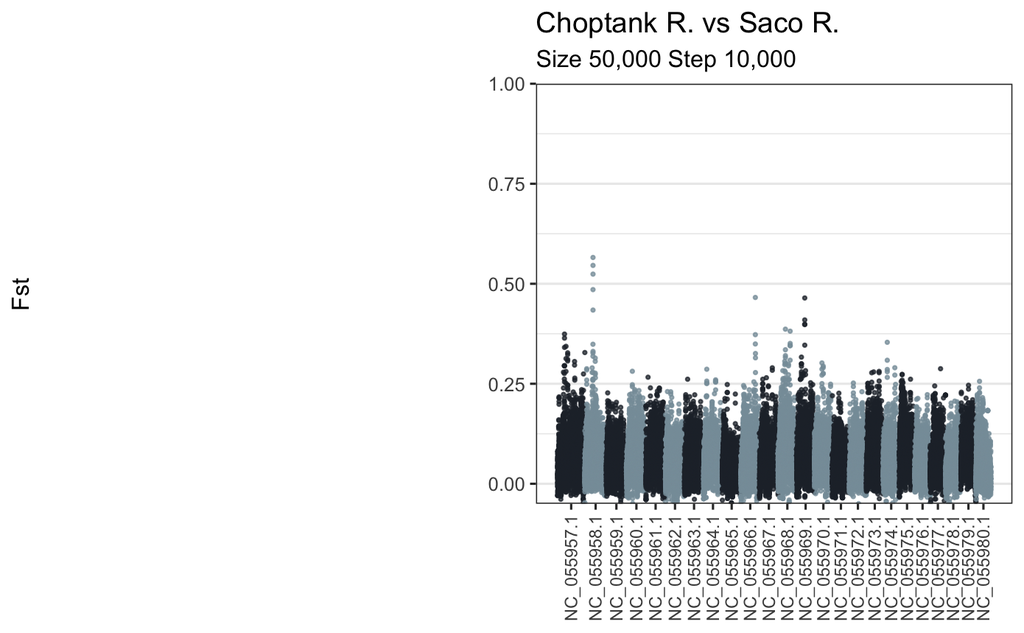

```r
ChR_ScR_plot <- ggplot(data = ChR_ScR,
                       mapping = aes(x = pos_cum,
                                     y = Fst,
                                     color = as_factor(chr))) +
  geom_point(alpha = 0.75, size = 0.5) +
  scale_x_continuous(label = ChR_ScR_axis_set$chr,
                     breaks = ChR_ScR_axis_set$center) +
  scale_y_continuous(expand = c(0,0),
                     limits = c(-0.05, 1)) +
  scale_color_manual(values = rep(c("#242b35", "#869ca8"),
                                  unique(length(ChR_ScR_axis_set$chr)))) +
  labs(x = NULL,
       y = "Fst",
       title = "Choptank R. vs Saco R.",
       subtitle = "Size 50,000 Step 10,000") +
  theme_bw() +
  theme(legend.position = "none",
        panel.grid.major.x = element_blank(),
        panel.grid.minor.x = element_blank(),
        axis.title.y = element_markdown(),
        axis.text.x = element_text(angle = 90,
                                  size = 8,
                                  vjust = 0.5))
ChR_ScR_plot
```

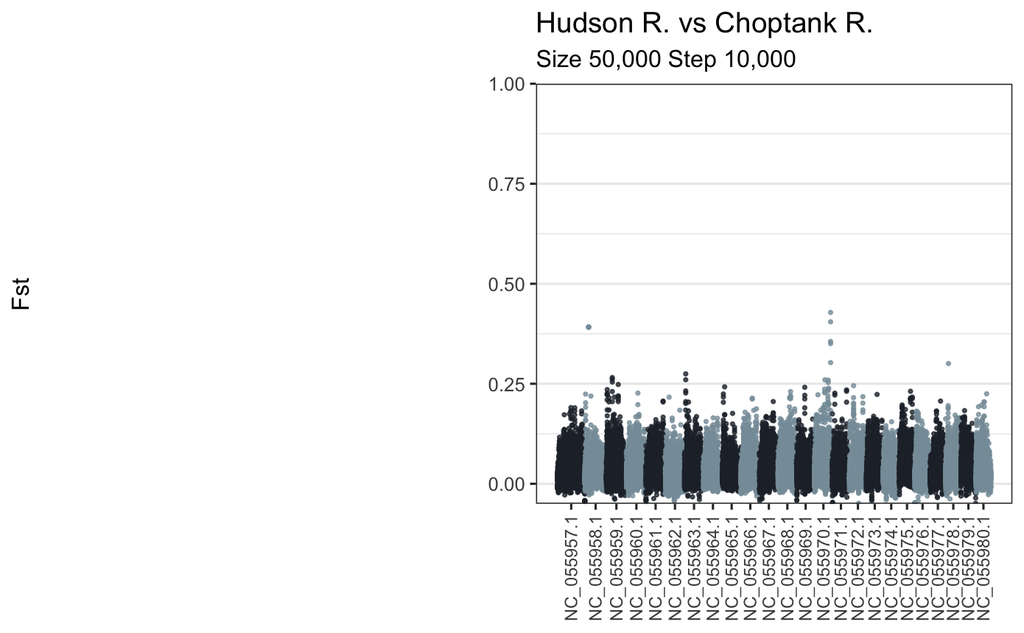

```r
HdR_ChR_plot <- ggplot(data = HdR_ChR,
                       mapping = aes(x = pos_cum,
                                     y = Fst,
                                     color = as_factor(chr))) +
  geom_point(alpha = 0.75, size = 0.5) +
  scale_x_continuous(label = HdR_ChR_axis_set$chr,
                     breaks = HdR_ChR_axis_set$center) +
  scale_y_continuous(expand = c(0,0),
                     limits = c(-0.05, 1)) +
  scale_color_manual(values = rep(c("#242b35", "#869ca8"),
                                  unique(length(HdR_ChR_axis_set$chr)))) +
  labs(x = NULL,
       y = "Fst",
       title = "Hudson R. vs Choptank R.",
       subtitle = "Size 50,000 Step 10,000") +
  theme_bw() +
  theme(legend.position = "none",
        panel.grid.major.x = element_blank(),
        panel.grid.minor.x = element_blank(),
        axis.title.y = element_markdown(),
        axis.text.x = element_text(angle = 90,
                                  size = 8,
                                  vjust = 0.5))
HdR_ChR_plot
```

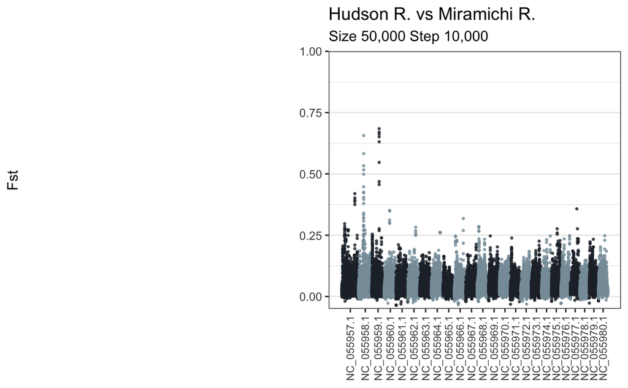

```r
HdR_MrR_plot <- ggplot(data = HdR_MrR,
                       mapping = aes(x = pos_cum,
                                     y = Fst,
                                     color = as_factor(chr))) +
  geom_point(alpha = 0.75, size = 0.5) +
  scale_x_continuous(label = HdR_MrR_axis_set$chr,
                     breaks = HdR_MrR_axis_set$center) +
  scale_y_continuous(expand = c(0,0),
                     limits = c(-0.05, 1)) +
  scale_color_manual(values = rep(c("#242b35", "#869ca8"),
                                  unique(length(HdR_MrR_axis_set$chr)))) +
  labs(x = NULL,
       y = "Fst",
       title = "Hudson R. vs Miramichi R.",
       subtitle = "Size 50,000 Step 10,000") +
  theme_bw() +
  theme(legend.position = "none",
        panel.grid.major.x = element_blank(),
        panel.grid.minor.x = element_blank(),
        axis.title.y = element_markdown(),
        axis.text.x = element_text(angle = 90,
                                  size = 8,
                                  vjust = 0.5))
HdR_MrR_plot
```

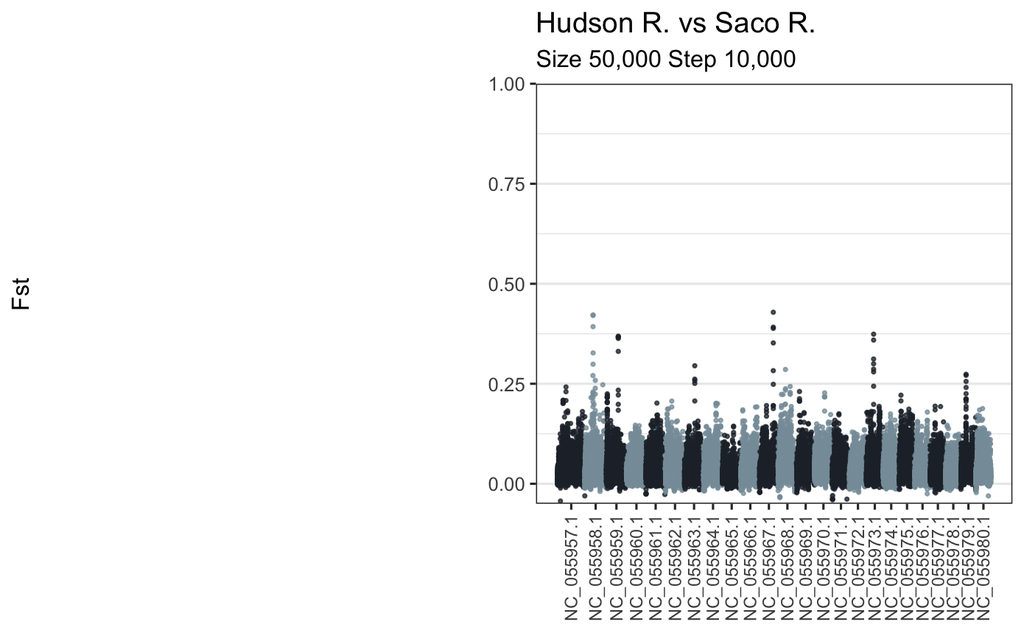

```r
HdR_ScR_plot <- ggplot(data = HdR_ScR,
                       mapping = aes(x = pos_cum,
                                     y = Fst,
                                     color = as_factor(chr))) +
  geom_point(alpha = 0.75, size = 0.5) +
  scale_x_continuous(label = HdR_ScR_axis_set$chr,
                     breaks = HdR_ScR_axis_set$center) +
  scale_y_continuous(expand = c(0,0),
                     limits = c(-0.05, 1)) +
  scale_color_manual(values = rep(c("#242b35", "#869ca8"),
                                  unique(length(HdR_ScR_axis_set$chr)))) +
  labs(x = NULL,
       y = "Fst",
       title = "Hudson R. vs Saco R.",
       subtitle = "Size 50,000 Step 10,000") +
  theme_bw() +
  theme(legend.position = "none",
        panel.grid.major.x = element_blank(),
        panel.grid.minor.x = element_blank(),
        axis.title.y = element_markdown(),
        axis.text.x = element_text(angle = 90,
                                  size = 8,
                                  vjust = 0.5))
HdR_ScR_plot
```

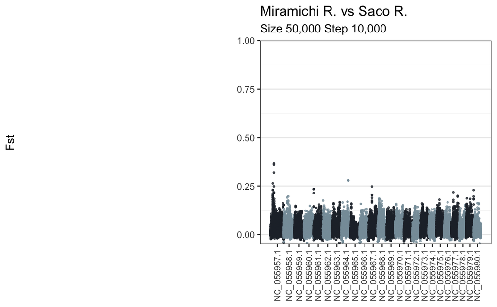

```r
MrR_ScR_plot <- ggplot(data = MrR_ScR,
                       mapping = aes(x = pos_cum,
                                     y = Fst,
                                     color = as_factor(chr))) +
  geom_point(alpha = 0.75, size = 0.5) +
  scale_x_continuous(label = MrR_ScR_axis_set$chr,
                     breaks = MrR_ScR_axis_set$center) +
  scale_y_continuous(expand = c(0,0),
                     limits = c(-0.05, 1)) +
  scale_color_manual(values = rep(c("#242b35", "#869ca8"),
                                  unique(length(MrR_ScR_axis_set$chr)))) +
  labs(x = NULL,
       y = "Fst",
       title = "Miramichi R. vs Saco R.",
       subtitle = "Size 50,000 Step 10,000") +
  theme_bw() +
  theme(legend.position = "none",
        panel.grid.major.x = element_blank(),
        panel.grid.minor.x = element_blank(),
        axis.title.y = element_markdown(),
        axis.text.x = element_text(angle = 90,
                                  size = 8,
                                  vjust = 0.5))
MrR_ScR_plot
```

```r
### Using ggsave to save the manhattan plots, or as I will now refer to it: ###
# Saving Private Plots (Ryan lol) ##
ggsave("figures/sliding-windows-fst/MIDA-x-NATLA-sz50-chrom19-spike.png",
       plot = mxn50_chr19_spike_plot,
       width = 10,
       height = 4)
```

Hudson River appears to be driving the difference on the chromosome 3 peak. Both Saco River and Miramichi River are both different on the chromosome 2 peak, though Miramichi River seems to be driving the difference to be over 50%. Miramichi River and Saco River are in different managing units, where Miramichi R. is part of the Canada MU and Saco River is part of the Northern New England MU. Hudson River, Choptank River, and Black Creek are part of the Mid-Atlantic MU which is why we see a lower average genome-wide FST, particularly between Black Creek and Hudson River as Black C. is part of the Hudson R. watershed. I believe more samples from the Canada MU are needed to assess the origins of the Great Lakes alewife populations to be able to make a concrete case. Ideally, I would be able to also include the Southern New England MU (for which we have no anadromous low-coverage whole-genome sequences in this dataset).